# Modelling Spike-at-Zero Covariates with Fractional Polynomials

Edwin Kipruto and Willi Sauerbrei

# 1 Introduction

A spike-at-zero (SAZ) covariate has a proportion of observations equal to zero and a continuous distribution of positive values. In `mfp2()`, setting `spike = TRUE` inside `fp()` models such a covariate with two components: a binary indicator $I(x = 0)$ and an FP function of the positive values. The selection procedure then decides which components to keep.

This vignette shows how to run the analyses in the accompanying paper (paper reference) and how to read the output. For the model, the selection procedures and the eligibility rules, each section points to the relevant part of the paper.

Every SAZ fit reports one of four `saz_decision` values (paper, Section 2.3):

| `saz_decision` | Retained components | Paper notation |
| --- | --- | --- |
| `continuous + binary` | FP function and binary indicator | $M_{BP}$ |
| `continuous only` | FP function of positive values only | $M_P$ |
| `binary only` | Binary indicator only | $M_B$ |
| `not selected` | None (covariate excluded) | – |

```r
library(mfp2)

data("prostate", package = "mfp2")
```

# 2 Prostate cancer data

The outcome is `lpsa` (log prostate-specific antigen). The SAZ candidate is `pgg45`, the percentage of Gleason score 4 or 5 (paper, Section 4.1).

```r
nrow(prostate)
```

```
#> [1] 97
```

```r
table(pgg45_zero = prostate$pgg45 == 0)
```

```
#> pgg45_zero
#> FALSE  TRUE
#>    62    35
```

```r
round(mean(prostate$pgg45 == 0), 2)
```

```
#> [1] 0.36
```

```r
length(unique(prostate$pgg45[prostate$pgg45 > 0]))  # distinct positive values
```

```
#> [1] 18
```

The zero proportion (0.36) and the positive proportion (0.64) are both above the default threshold `min_saz_prop = 0.10`, so `pgg45` is eligible for SAZ modelling (paper, Section 3.2).

## 2.1 Univariable analysis with p-values

```r
fit_pgg45 <- mfp2(
  lpsa ~ fp(pgg45, df = 4, select = 0.05, alpha = 0.05, spike = TRUE),
  data = prostate,
  family = "gaussian",
  criterion = "pvalue",
  verbose = FALSE
)

print(fit_pgg45, detailed_settings = FALSE, notes = FALSE)
```

```
#> ==============================================================================
#> MFP Model Fit
#> ==============================================================================
#>
#> Call:
#> mfp2(lpsa ~ fp(pgg45, df = 4, select = 0.05, alpha = 0.05, spike = TRUE),
#>     data = prostate, family = "gaussian", criterion = "pvalue",
#>     verbose = FALSE)
#>
#> Model: Gaussian GLM (identity link) | Criterion: p-value | Converged: yes
#> Observations: 97
#> Dispersion: 1.031 (estimated)
#>
#> ------------------------------------------------------------------------------
#> Selection Summary
#> ------------------------------------------------------------------------------
#>
#> Selected variables (linear): pgg45
#> Selected variables (nonlinear): none
#> Excluded variables: none
#>
#> ------------------------------------------------------------------------------
#> Covariate Preprocessing
#> ------------------------------------------------------------------------------
#>
#>       shift scale center
#> pgg45 0     1     TRUE
#>
#> ------------------------------------------------------------------------------
#> Summary of Function Selection
#> ------------------------------------------------------------------------------
#>
#> Spike-at-Zero (SAZ; x is transformed only for x > 0, binary is I(x = 0))
#> ------------------------------------------------------------------------
#>  Variable prop_zero df (init->final) saz_decision Function
#>  pgg45    0.361     5 -> 1           binary only  binary
#>
#> ------------------------------------------------------------------------------
#> Final Model Coefficients
#> ------------------------------------------------------------------------------
#>
#> Estimates are for: Basis - Center
#>
#>  Variable    Basis        Center Estimate SE
#>  (Intercept)                     2.896    0.129
#>  pgg45       I(pgg45 = 0) 0.000  -1.158   0.215
#>
#> ------------------------------------------------------------------------------
#> Model Fit
#> ------------------------------------------------------------------------------
#>
#>                    Deviance    df
#> Full linear model    95.416     2
#> MFP model            97.931     1
#>
#>
#> ==============================================================================
```

What the arguments do (all except `spike` are the defaults):

- `spike = TRUE` requests the SAZ decomposition.
- `df = 4` allows at most an FP2 function for the positive values.
- `select` is the significance level for including the covariate.
- `alpha` is the significance level for choosing the FP function and for the tests that remove a component (paper, Sections 2.3.1–2.3.2).
- `detailed_settings = FALSE` and `notes = FALSE` shorten the printed output.

The selected model is `binary only`: the FP function is dropped, so every positive value of `pgg45` gets the same fitted value (paper, Section 4.2).

`predict()` takes covariates on their original scale and builds the indicator and FP terms itself:

```r
newdat <- data.frame(pgg45 = c(0, 4, 20, 45, 60, 100))
predict(fit_pgg45, newdata = newdat, type = "link")
```

```
#>        1        2        3        4        5        6
#> 1.738370 2.896138 2.896138 2.896138 2.896138 2.896138
```

The prediction is about 1.74 at zero and about 2.90 at every positive value.

`plot()` returns a list of ggplot objects, one per covariate. `partial_only = TRUE` plots only the fitted effect, without partial residuals. A `binary only` effect shows as two points with confidence intervals. The intervals do not account for model selection.

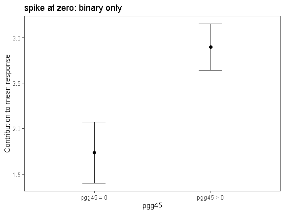

Binary-only SAZ model for pgg45 (paper, Figure 1).

```r
p1 <- plot(fit_pgg45, terms = "pgg45", partial_only = TRUE)
p1[["pgg45"]]
```

## 2.2 Forcing inclusion or the full SAZ model

Three settings override parts of the selection (paper, Section 3.1 and the table of arguments there).

**`select = 1`** keeps `pgg45` in the model. `alpha` still controls the choice of FP function and the removal of components, so any SAZ decision except `not selected` can result.

```r
fit_forced <- mfp2(
  lpsa ~ fp(pgg45, select = 1, alpha = 0.05, spike = TRUE),
  data = prostate,
  family = gaussian(),
  criterion = "pvalue",
  verbose = FALSE
)
print(fit_forced, detailed_settings = FALSE, notes = FALSE)
```

```
#> ==============================================================================
#> MFP Model Fit
#> ==============================================================================
#>
#> Call:
#> mfp2(lpsa ~ fp(pgg45, select = 1, alpha = 0.05, spike = TRUE),
#>     data = prostate, family = gaussian(), criterion = "pvalue",
#>     verbose = FALSE)
#>
#> Model: Gaussian GLM (identity link) | Criterion: p-value | Converged: yes
#> Observations: 97
#> Dispersion: 1.031 (estimated)
#>
#> ------------------------------------------------------------------------------
#> Selection Summary
#> ------------------------------------------------------------------------------
#>
#> Selected variables (linear): pgg45
#> Selected variables (nonlinear): none
#> Excluded variables: none
#>
#> ------------------------------------------------------------------------------
#> Covariate Preprocessing
#> ------------------------------------------------------------------------------
#>
#>       shift scale center
#> pgg45 0     1     TRUE
#>
#> ------------------------------------------------------------------------------
#> Summary of Function Selection
#> ------------------------------------------------------------------------------
#>
#> Spike-at-Zero (SAZ; x is transformed only for x > 0, binary is I(x = 0))
#> ------------------------------------------------------------------------
#>  Variable prop_zero df (init->final) saz_decision Function
#>  pgg45    0.361     5 -> 1           binary only  binary
#>
#> ------------------------------------------------------------------------------
#> Final Model Coefficients
#> ------------------------------------------------------------------------------
#>
#> Estimates are for: Basis - Center
#>
#>  Variable    Basis        Center Estimate SE
#>  (Intercept)                     2.896    0.129
#>  pgg45       I(pgg45 = 0) 0.000  -1.158   0.215
#>
#> ------------------------------------------------------------------------------
#> Model Fit
#> ------------------------------------------------------------------------------
#>
#>                    Deviance    df
#> Full linear model    95.416     2
#> MFP model            97.931     1
#>
#>
#> ==============================================================================
```

**`keep`** does the same for any `criterion`. It is an argument of `mfp2()`, not of `fp()`, and takes variable names. The multivariable model in the next section excludes `pgg45`; `keep = "pgg45"` keeps it in:

```r
fit_keep <- mfp2(
  lpsa ~ fp(pgg45, spike = TRUE) + fp(age) +
    fp(cavol) + fp(weight) + fp(bph) + fp(cp) + svi,
  data = prostate,
  family = gaussian(),
  criterion = "pvalue",
  select = 0.05,
  alpha = 0.05,
  keep = "pgg45",
  verbose = FALSE
)
print(fit_keep, detailed_settings = FALSE, notes = FALSE)
```

```
#> ==============================================================================
#> MFP Model Fit
#> ==============================================================================
#>
#> Call:
#> mfp2(lpsa ~ fp(pgg45, spike = TRUE) + fp(age) + fp(cavol) + fp(weight) +
#>     fp(bph) + fp(cp) + svi, data = prostate, family = gaussian(),
#>     criterion = "pvalue", select = 0.05, alpha = 0.05, keep = "pgg45",
#>     verbose = FALSE)
#>
#> Model: Gaussian GLM (identity link) | Criterion: p-value | Converged: yes
#> Observations: 97
#> Dispersion: 0.499 (estimated)
#>
#> ------------------------------------------------------------------------------
#> Selection Summary
#> ------------------------------------------------------------------------------
#>
#> Selected variables (linear): svi, pgg45, weight
#> Selected variables (nonlinear): cavol
#> Excluded variables: bph, cp, age
#>
#> ------------------------------------------------------------------------------
#> Covariate Preprocessing
#> ------------------------------------------------------------------------------
#>
#>        shift scale center
#> cavol  0     10    TRUE
#> svi    0     1     TRUE
#> pgg45  0     1     TRUE
#> weight 0     100   TRUE
#> bph    0     1     TRUE
#> cp     0     10    TRUE
#> age    0     10    TRUE
#>
#> ------------------------------------------------------------------------------
#> Summary of Function Selection
#> ------------------------------------------------------------------------------
#>
#> Standard MFP
```

[output cut: 22 more lines]

```
#>  cavol       log(cavol)   1.350  0.497    0.079
#>  svi         svi          0.000  0.626    0.210
#>  pgg45       I(pgg45 = 0) 0.000  -0.262   0.175
#>  weight      weight       41.310 0.014    0.004
#>
#> ------------------------------------------------------------------------------
#> Model Fit
#> ------------------------------------------------------------------------------
#>
#>                    Deviance    df
#> Full linear model    49.471     8
#> MFP model            45.891     5
#>
#>
#> ==============================================================================
```

**`force_max_fp = TRUE`** in `fp()` keeps the binary indicator and the most complex FP function allowed by `df` (FP2 here). Components are not removed, whatever the criterion.

```r
fit_maxfp <- mfp2(
  lpsa ~ fp(pgg45, spike = TRUE, force_max_fp = TRUE),
  data = prostate,
  family = gaussian(),
  criterion = "pvalue",
  verbose = FALSE
)
print(fit_maxfp, detailed_settings = FALSE, notes = FALSE)
```

```
#> ==============================================================================
#> MFP Model Fit
#> ==============================================================================
#>
#> Call:
#> mfp2(lpsa ~ fp(pgg45, spike = TRUE, force_max_fp = TRUE), data = prostate,
#>     family = gaussian(), criterion = "pvalue", verbose = FALSE)
#>
#> Model: Gaussian GLM (identity link) | Criterion: p-value | Converged: yes
#> Observations: 97
#> Dispersion: 1.012 (estimated)
#>
#> ------------------------------------------------------------------------------
#> Selection Summary
#> ------------------------------------------------------------------------------
#>
#> Selected variables (linear): none
#> Selected variables (nonlinear): pgg45
#> Excluded variables: none
#>
#> ------------------------------------------------------------------------------
#> Covariate Preprocessing
#> ------------------------------------------------------------------------------
#>
#>       shift scale center
#> pgg45 0     1     TRUE
#>
#> ------------------------------------------------------------------------------
#> Summary of Function Selection
#> ------------------------------------------------------------------------------
#>
#> Spike-at-Zero (SAZ; x is transformed only for x > 0, binary is I(x = 0))
#> ------------------------------------------------------------------------
#>  Variable prop_zero df (init->final) saz_decision        Function
#>  pgg45    0.361     5 -> 5           continuous + binary FP(1, 3) + binary
#>
#> ------------------------------------------------------------------------------
#> Final Model Coefficients
#> ------------------------------------------------------------------------------
#>
#> Estimates are for: Basis - Center
#>
#>  Variable    Basis                  Center    Estimate SE
#>  (Intercept)                                  2.718    0.158
#>  pgg45       I(pgg45 > 0) * pgg45   24.381    0.019    0.011
#>              I(pgg45 > 0) * pgg45^3 93130.464 -0.000   0.000
#>              I(pgg45 = 0)           0.000     -0.663   0.333
#>
#> ------------------------------------------------------------------------------
#> Model Fit
#> ------------------------------------------------------------------------------
#>
#>                    Deviance    df
#> Full linear model    95.416     2
#> MFP model            94.072     5
#>
#>
#> ==============================================================================
```

## 2.3 Multivariable analysis

SAZ covariates can be mixed with ordinary FP covariates and with binary covariates entered without `fp()` (here `svi`). The SAZ decision for `pgg45` is made in each backfitting cycle, given the current functions of the other covariates (paper, Section 2.4). Settings passed to `mfp2()` (`select`, `alpha`) apply to all covariates unless overridden inside `fp()`.

```r
fit_multi <- mfp2(
  lpsa ~ fp(pgg45, spike = TRUE) + fp(age) +
    fp(cavol) + fp(weight) + fp(bph) + fp(cp) + svi,
  data = prostate,
  family = gaussian(),
  criterion = "pvalue",
  select = 0.05,
  alpha = 0.05,
  verbose = FALSE
)
print(fit_multi, detailed_settings = FALSE, notes = FALSE)
```

```
#> ==============================================================================
#> MFP Model Fit
#> ==============================================================================
#>
#> Call:
#> mfp2(lpsa ~ fp(pgg45, spike = TRUE) + fp(age) + fp(cavol) + fp(weight) +
#>     fp(bph) + fp(cp) + svi, data = prostate, family = gaussian(),
#>     criterion = "pvalue", select = 0.05, alpha = 0.05, verbose = FALSE)
#>
#> Model: Gaussian GLM (identity link) | Criterion: p-value | Converged: yes
#> Observations: 97
#> Dispersion: 0.505 (estimated)
#>
#> ------------------------------------------------------------------------------
#> Selection Summary
#> ------------------------------------------------------------------------------
#>
#> Selected variables (linear): svi, weight
#> Selected variables (nonlinear): cavol
#> Excluded variables: pgg45, bph, cp, age
#>
#> ------------------------------------------------------------------------------
#> Covariate Preprocessing
#> ------------------------------------------------------------------------------
#>
#>        shift scale center
#> cavol  0     10    TRUE
#> svi    0     1     TRUE
#> pgg45  0     1     TRUE
#> weight 0     100   TRUE
#> bph    0     1     TRUE
#> cp     0     10    TRUE
#> age    0     10    TRUE
#>
#> ------------------------------------------------------------------------------
#> Summary of Function Selection
#> ------------------------------------------------------------------------------
#>
#> Standard MFP
#> ------------
```

[output cut: 20 more lines]

```
#>  (Intercept)                   2.331    0.085
#>  cavol       log(cavol) 1.350  0.540    0.074
#>  svi         svi        0.000  0.679    0.208
#>  weight      weight     41.310 0.014    0.004
#>
#> ------------------------------------------------------------------------------
#> Model Fit
#> ------------------------------------------------------------------------------
#>
#>                    Deviance    df
#> Full linear model    49.471     8
#> MFP model            47.004     4
#>
#>
#> ==============================================================================
```

After adjustment, `pgg45` is `not selected`. Only `cavol` (log), `weight` (linear) and `svi` are retained (paper, Section 4.3).

## 2.4 Selection with AIC or BIC

With `criterion = "aic"` or `"bic"`, all candidate SAZ models are compared in a single step and `select` and `alpha` are ignored (paper, Sections 2.3.3 and 4.4).

```r
fit_pgg45_aic <- mfp2(
  lpsa ~ fp(pgg45, spike = TRUE),
  data = prostate,
  family = "gaussian",
  criterion = "aic",
  verbose = FALSE
)
print(fit_pgg45_aic, detailed_settings = FALSE, notes = FALSE)
```

```
#> ==============================================================================
#> MFP Model Fit
#> ==============================================================================
#>
#> Call:
#> mfp2(lpsa ~ fp(pgg45, spike = TRUE), data = prostate, family = "gaussian",
#>     criterion = "aic", verbose = FALSE)
#>
#> Model: Gaussian GLM (identity link) | Criterion: AIC | Converged: yes
#> Observations: 97
#> Dispersion: 0.999 (estimated)
#>
#> ------------------------------------------------------------------------------
#> Selection Summary
#> ------------------------------------------------------------------------------
#>
#> Selected variables (linear): none
#> Selected variables (nonlinear): pgg45
#> Excluded variables: none
#>
#> ------------------------------------------------------------------------------
#> Covariate Preprocessing
#> ------------------------------------------------------------------------------
#>
#>       shift scale center
#> pgg45 0     1     TRUE
#>
#> ------------------------------------------------------------------------------
#> Summary of Function Selection
#> ------------------------------------------------------------------------------
#>
#> Spike-at-Zero (SAZ; x is transformed only for x > 0, binary is I(x = 0))
#> ------------------------------------------------------------------------
#>  Variable prop_zero df (init->final) saz_decision    Function
#>  pgg45    0.361     5 -> 2           continuous only FP(0)
#>
#> ------------------------------------------------------------------------------
#> Final Model Coefficients
#> ------------------------------------------------------------------------------
#>
#> Estimates are for: Basis - Center
#>
#>  Variable    Basis                     Center Estimate SE
#>  (Intercept)                                  2.478    0.101
#>  pgg45       I(pgg45 > 0) * log(pgg45) 2.117  0.334    0.058
#>
#> ------------------------------------------------------------------------------
#> Model Fit
#> ------------------------------------------------------------------------------
#>
#>                    Deviance    df
#> Full linear model    95.416     2
#> MFP model            94.871     2
#>
#>
#> ==============================================================================
```

AIC penalises extra parameters less than the 0.05 p-value test does, and selects `continuous only` with a log function. There is no binary indicator. For `pgg45 = 0` the FP term is set to zero (`log(0)` is not computed), so the prediction at zero is the uncentred intercept. This equals the fitted log function at `pgg45 = 1`.

```r
newdat <- data.frame(pgg45 = c(0, 4, 25, 100))
predict(fit_pgg45_aic, newdata = newdat, type = "link")
```

```
#>        1        2        3        4
#> 1.771067 2.234322 2.846712 3.309967
```

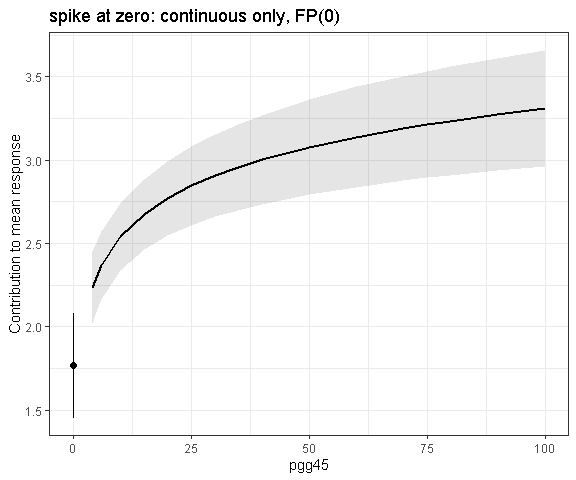

Continuous-only SAZ model for pgg45 selected by AIC (paper, Figure 2).

```r
p2 <- plot(fit_pgg45_aic, terms = "pgg45", partial_only = TRUE,
           show_grid = TRUE)
p2[["pgg45"]]
```

BIC penalises extra parameters more than AIC does, and selects `binary only`, the same result as the p-value analysis:

```r
fit_pgg45_bic <- mfp2(
  lpsa ~ fp(pgg45, spike = TRUE),
  data = prostate,
  family = "gaussian",
  criterion = "bic",
  verbose = FALSE
)
print(fit_pgg45_bic, detailed_settings = FALSE, notes = FALSE)
```

```
#> ==============================================================================
#> MFP Model Fit
#> ==============================================================================
#>
#> Call:
#> mfp2(lpsa ~ fp(pgg45, spike = TRUE), data = prostate, family = "gaussian",
#>     criterion = "bic", verbose = FALSE)
#>
#> Model: Gaussian GLM (identity link) | Criterion: BIC | Converged: yes
#> Observations: 97
#> Dispersion: 1.031 (estimated)
#>
#> ------------------------------------------------------------------------------
#> Selection Summary
#> ------------------------------------------------------------------------------
#>
#> Selected variables (linear): pgg45
#> Selected variables (nonlinear): none
#> Excluded variables: none
#>
#> ------------------------------------------------------------------------------
#> Covariate Preprocessing
#> ------------------------------------------------------------------------------
#>
#>       shift scale center
#> pgg45 0     1     TRUE
#>
#> ------------------------------------------------------------------------------
#> Summary of Function Selection
#> ------------------------------------------------------------------------------
#>
#> Spike-at-Zero (SAZ; x is transformed only for x > 0, binary is I(x = 0))
#> ------------------------------------------------------------------------
#>  Variable prop_zero df (init->final) saz_decision Function
#>  pgg45    0.361     5 -> 1           binary only  binary
#>
#> ------------------------------------------------------------------------------
#> Final Model Coefficients
#> ------------------------------------------------------------------------------
#>
#> Estimates are for: Basis - Center
#>
#>  Variable    Basis        Center Estimate SE
#>  (Intercept)                     2.896    0.129
#>  pgg45       I(pgg45 = 0) 0.000  -1.158   0.215
#>
#> ------------------------------------------------------------------------------
#> Model Fit
#> ------------------------------------------------------------------------------
#>
#>                    Deviance    df
#> Full linear model    95.416     2
#> MFP model            97.931     1
#>
#>
#> ==============================================================================
```

# 3 Simulated data: continuous + binary

The prostate data do not produce `continuous + binary`. Section 4.5 of the paper therefore simulates data from its Equation 14: an FP2 function with powers (0.5, 1) for positive values, a binary effect $\gamma = 2$, and about 30% zeros.

```r
set.seed(2107)
n <- 5000

is_zero <- rbinom(n, size = 1, prob = 0.30) == 1
x_saz <- ifelse(is_zero, 0, runif(n, min = 1, max = 12))

# True FP2 function for positive values; 0 at x = 0
positive <- x_saz > 0
f_saz <- numeric(n)
f_saz[positive] <- 4.0 * sqrt(x_saz[positive]) - 0.9 * x_saz[positive]

alpha <- 1.5  # intercept
gamma <- 2.0  # binary-indicator effect
z_saz <- as.numeric(x_saz == 0)
y <- alpha + gamma * z_saz + f_saz + rnorm(n, sd = 1)

dat_bincont <- data.frame(y = y, x_saz = x_saz)
```

`center = FALSE` makes the coefficients directly comparable with the generating values.

```r
fit_bincont <- mfp2(
  y ~ fp(x_saz, center = FALSE, spike = TRUE),
  data = dat_bincont,
  family = gaussian(),
  criterion = "pvalue",
  min_saz_prop = 0.10,
  verbose = FALSE
)
print(fit_bincont, detailed_settings = FALSE, notes = FALSE)

predict(fit_bincont, newdata = data.frame(x_saz = c(0, 1, 5, 7, 12)))

p3 <- plot(fit_bincont, terms = "x_saz", partial_only = TRUE,
           show_grid = TRUE)
p3[["x_saz"]]
```

Results reported in the paper:

| Parameter | True | Estimate (SE) |
| --- | --- | --- |
| Intercept $\alpha$ | 1.5 | 1.578 (0.212) |
| $x^{0.5}$ | 4.0 | 3.977 (0.190) |
| $x$ | -0.9 | -0.904 (0.040) |
| Binary $\gamma$ | 2.0 | 1.930 (0.213) |

The selected model is `continuous + binary` with powers (0.5, 1). The prediction at zero is $\hat\alpha + \hat\gamma \approx 3.51$. Over the positive values, the predictions rise to a peak near $x = 5$ and then fall (paper, Figure 3).

# 4 Several SAZ covariates in one model

Appendix A of the paper simulates three SAZ covariates, one for each retained decision, plus an ordinary FP covariate (`x4`) and two noise covariates (`x5`, `x6`). Each SAZ covariate gets its own decision within the backfitting.

```r
set.seed(2107)
n <- 10000
p <- 6
rho <- 0.20
mu <- rep(3, p)
sigma <- 0.60
Sigma <- matrix(rho * sigma^2, nrow = p, ncol = p)
diag(Sigma) <- sigma^2

repeat {
  X <- MASS::mvrnorm(n = n, mu = mu, Sigma = Sigma)
  if (all(X > 0)) break
}
colnames(X) <- paste0("x", 1:6)
x1 <- X[, 1]; x2 <- X[, 2]; x3 <- X[, 3]
x4 <- X[, 4]; x5 <- X[, 5]; x6 <- X[, 6]

# Introduce zeros in the three SAZ covariates
x1[rbinom(n, 1, 0.30) == 1] <- 0
x2[rbinom(n, 1, 0.25) == 1] <- 0
x3[rbinom(n, 1, 0.35) == 1] <- 0

# FP transformation of positive values; 0 at x = 0
positive_fp <- function(x, power) {
  out <- numeric(length(x))
  pos <- x > 0
  out[pos] <- if (power == 0) log(x[pos]) else x[pos]^power
  out
}

# Linear predictor (paper, Equation 15)
eta <- 0.5 +
  20.00 * positive_fp(x1, -2) - 1.40 * (x1 == 0) +   # FP1 + binary
  15.00 * positive_fp(x2, -2) +
   0.25 * positive_fp(x2, 2) +                         # FP2 only
   1.40 * (x3 == 0) +                                  # binary only
   4.00 * log(x4)                                      # ordinary FP1

y <- eta + rnorm(n, mean = 0, sd = 0.80)
simdat <- data.frame(y, x1, x2, x3, x4, x5, x6)

colMeans(simdat[c("x1", "x2", "x3")] == 0)  # zero proportions
```

```r
fit_sim <- mfp2(
  y ~ fp(x1, spike = TRUE, center = FALSE) +
    fp(x2, spike = TRUE, center = FALSE) +
    fp(x3, spike = TRUE, center = FALSE) +
    fp(x4, center = FALSE) +
    fp(x5, center = FALSE) +
    fp(x6, center = FALSE),
  data = simdat,
  family = "gaussian",
  criterion = "bic",
  verbose = FALSE
)
print(fit_sim, detailed_settings = FALSE, notes = FALSE)
```

The paper reports that the true form is selected for every covariate:

| Covariate | `saz_decision` | Selected function |
| --- | --- | --- |
| `x1` | `continuous + binary` | FP(-2) + binary |
| `x2` | `continuous only` | FP(-2, 2) |
| `x3` | `binary only` | binary |
| `x4` | not SAZ | FP(0) (log) |
| `x5`, `x6` | not SAZ | excluded |

All estimated coefficients are close to the generating values (paper, Appendix A). This is one sample, so it does not show how often the correct model is selected.

# 5 Matrix interface

```r
y <- prostate$lpsa
x <- as.matrix(prostate[, "pgg45", drop = FALSE])  # drop = FALSE keeps a matrix
x_multi <- as.matrix(
  prostate[, c("pgg45", "age", "cavol", "weight", "bph", "cp", "svi")]
)

fit_pgg45_mat <- mfp2(x, y, family = "gaussian", criterion = "pvalue",
                      select = 0.05, alpha = 0.05, spike_vars = "pgg45",
                      verbose = FALSE)

fit_multi_mat <- mfp2(x_multi, y, family = "gaussian", criterion = "pvalue",
                      select = 0.05, alpha = 0.05, spike_vars = "pgg45",
                      verbose = FALSE)

fit_aic_mat <- mfp2(x, y, family = "gaussian", criterion = "aic",
                    spike_vars = "pgg45", verbose = FALSE)

print(fit_pgg45_mat, detailed_settings = FALSE, notes = FALSE)
```

```
#> ==============================================================================
#> MFP Model Fit
#> ==============================================================================
#>
#> Call:
#> mfp2(x = x, y = y, family = "gaussian", criterion = "pvalue",
#>     select = 0.05, alpha = 0.05, spike_vars = "pgg45", verbose = FALSE)
#>
#> Model: Gaussian GLM (identity link) | Criterion: p-value | Converged: yes
#> Observations: 97
#> Dispersion: 1.031 (estimated)
#>
#> ------------------------------------------------------------------------------
#> Selection Summary
#> ------------------------------------------------------------------------------
#>
#> Selected variables (linear): pgg45
#> Selected variables (nonlinear): none
#> Excluded variables: none
#>
#> ------------------------------------------------------------------------------
#> Covariate Preprocessing
#> ------------------------------------------------------------------------------
#>
#>       shift scale center
#> pgg45 0     1     TRUE
#>
#> ------------------------------------------------------------------------------
#> Summary of Function Selection
#> ------------------------------------------------------------------------------
#>
#> Spike-at-Zero (SAZ; x is transformed only for x > 0, binary is I(x = 0))
#> ------------------------------------------------------------------------
#>  Variable prop_zero df (init->final) saz_decision Function
#>  pgg45    0.361     5 -> 1           binary only  binary
#>
#> ------------------------------------------------------------------------------
#> Final Model Coefficients
#> ------------------------------------------------------------------------------
#>
#> Estimates are for: Basis - Center
#>
#>  Variable    Basis        Center Estimate SE
#>  (Intercept)                     2.896    0.129
#>  pgg45       I(pgg45 = 0) 0.000  -1.158   0.215
#>
#> ------------------------------------------------------------------------------
#> Model Fit
#> ------------------------------------------------------------------------------
#>
#>                    Deviance    df
#> Full linear model    95.416     2
#> MFP model            97.931     1
#>
#>
#> ==============================================================================
```

# 6 Further details

See `?mfp2`, `?fp`, `?predict.mfp2` and `?plot.mfp2` for all arguments. The paper describes the SAZ model and selection procedures (Section 2), the software interface, eligibility checks and methods for fitted objects (Section 3), and discusses the results in more detail (Section 4 and Appendices A–B).

## 6.1 Paper reference

Kipruto, E., and Sauerbrei, W. *Modelling Spike-at-Zero Covariates with Fractional Polynomials in R*. Manuscript submitted to the *Journal of Statistical Software*.